# Biostat M280 Homework 2

Due Feb 16 @ 11:59PM

## Q1

Read [Chapter 7](http://r4ds.had.co.nz/exploratory-data-analysis.html) (Exploratory Data Analysis) of *R for Data Science* and do exercises 7.3.4, 7.4.1, 7.5.1.1, 7.5.2.1, and 7.5.3.1.

```
I read Chapter 7 and did exercises 7.3.4, 7.4.1, 7.5.1.1, 7.5.2.1, and 7.5.3.1.
```

7.3.4

1. Explore the distribution of each of the x, y, and z variables in diamonds. What do you learn? Think about a diamond and how you might decide which dimension is the length, width, and depth.

   The distribution of the x, y, and z variables in diamonds are right skewed, indicating that the sizes of most diamonds are small and only a few are large.

   The distribution of the x is very similar to that of y. In my opinion, x should be the length and y should be the width since they are close but the value of x is larger (more to the right) than that of y. And z should be the depth.

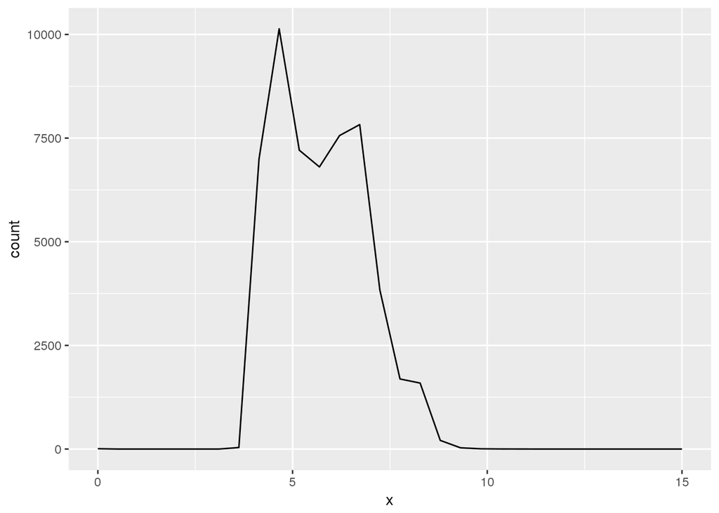

   ```r
   ggplot(diamonds, aes(x = x), binwidth = 0.01) +
     geom_freqpoly() +
     xlim(c(0, 15))
   ```

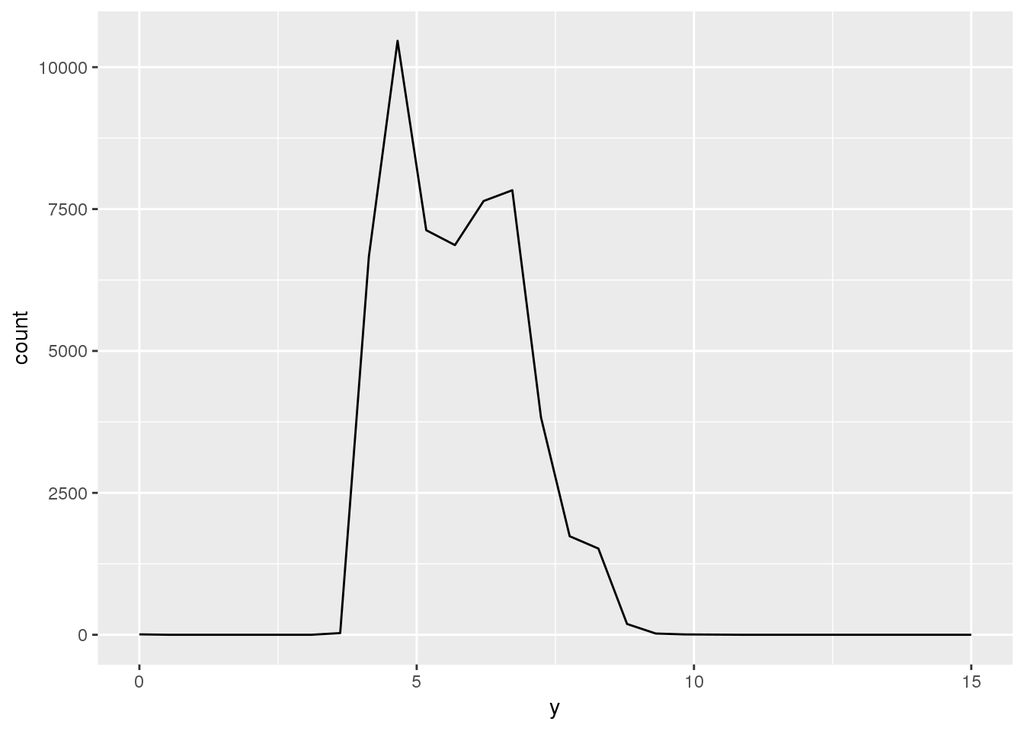

   ```r
   ggplot(diamonds, aes(x = y), binwidth = 0.01) +
     geom_freqpoly() +
     xlim(c(0, 15))
   ```

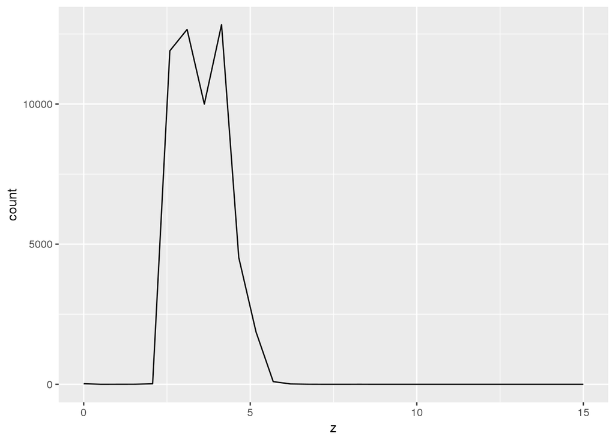

   ```r
   ggplot(diamonds, aes(x = z), binwidth = 0.01) +
     geom_freqpoly() +
     xlim(c(0, 15))
   ```

2. Explore the distribution of price. Do you discover anything unusual or surprising? (Hint: Carefully think about the binwidth and make sure you try a wide range of values.)

   In general, as the price of the diamonds went higher, the number of diamonds went lower.

   Something unusual: the number of diamonds is 0 when the price is 1500.

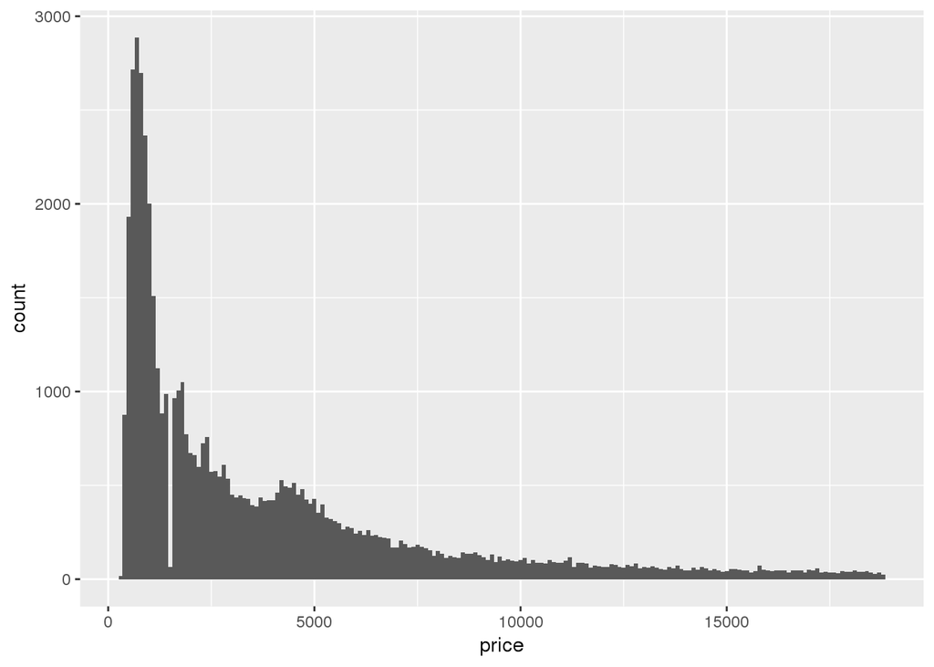

   ```r
   ggplot(data = diamonds) +
     geom_histogram(aes(x = price), binwidth = 100)
   ```

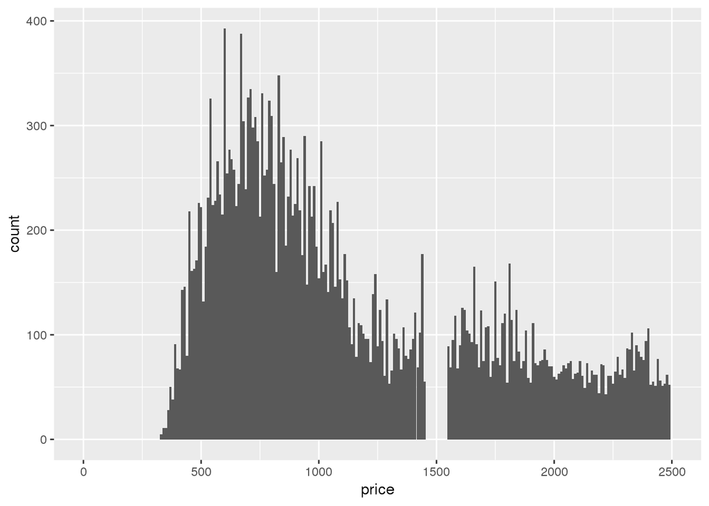

   ```r
   ggplot(data = diamonds) +
     geom_histogram(aes(x = price), binwidth = 10) +
     xlim(c(0, 2500))
   ```

3. How many diamonds are 0.99 carat? How many are 1 carat? What do you think is the cause of the difference?

   There are 23 diamonds that are 0.99 carat and 1558 diamonds that are 1 carat.

   I think the cause of the difference might be because diamonds of 0.99 carat can be made out of those of 1 carat. Therefore, there are much more diamonds of 1 carat than those of 0.99 carat.

   ```r
   diamonds %>%
     filter(carat %in% c(0.99, 1)) %>%
     count(carat)
   ```

   ```
   ## # A tibble: 2 x 2
   ##   carat     n
   ##   <dbl> <int>
   ## 1 0.990    23
   ## 2 1.00   1558
   ```

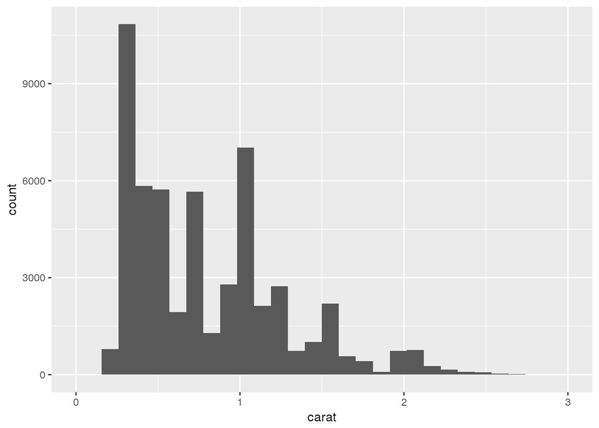

   ```r
   ggplot(diamonds, aes(x = carat), binwidth = 0.01) +
     geom_histogram() +
     xlim(c(0, 3))
   ```

4. Compare and contrast coord_cartesian() vs xlim() or ylim() when zooming in on a histogram. What happens if you leave binwidth unset? What happens if you try and zoom so only half a bar shows?

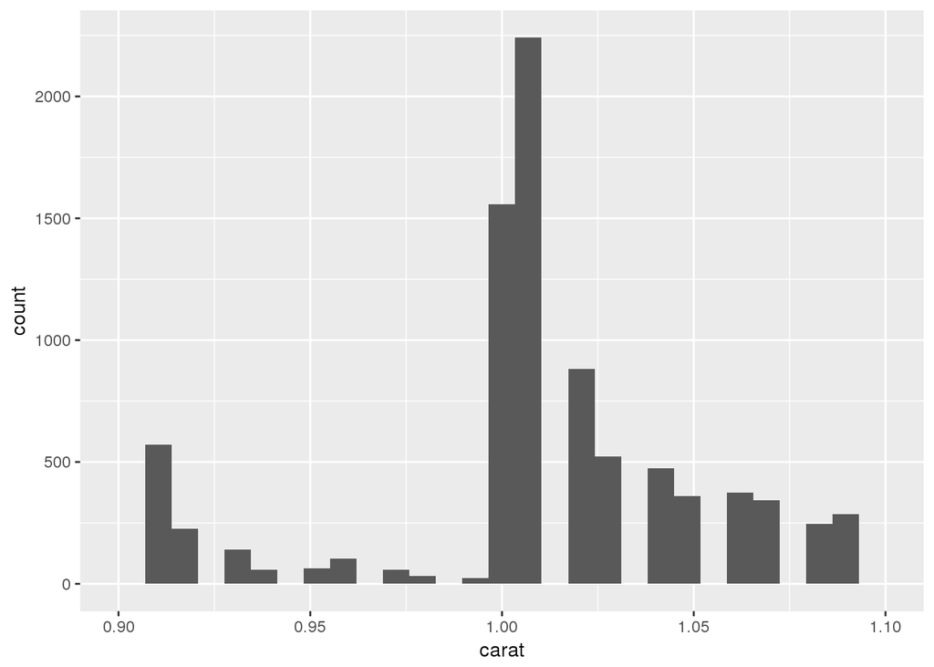

   ```r
   ggplot(diamonds, aes(x = carat)) +
     geom_histogram() +
     xlim(c(0.9, 1.1))
   ```

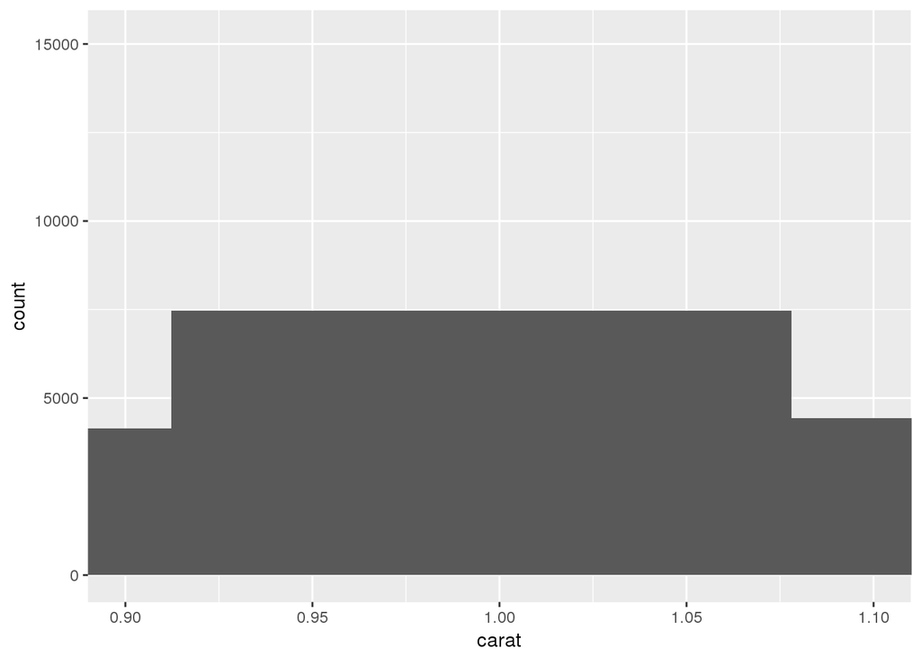

   ```r
   ggplot(diamonds, aes(x = carat)) +
     geom_histogram() +
     coord_cartesian(xlim = c(0.9, 1.1))
   ```

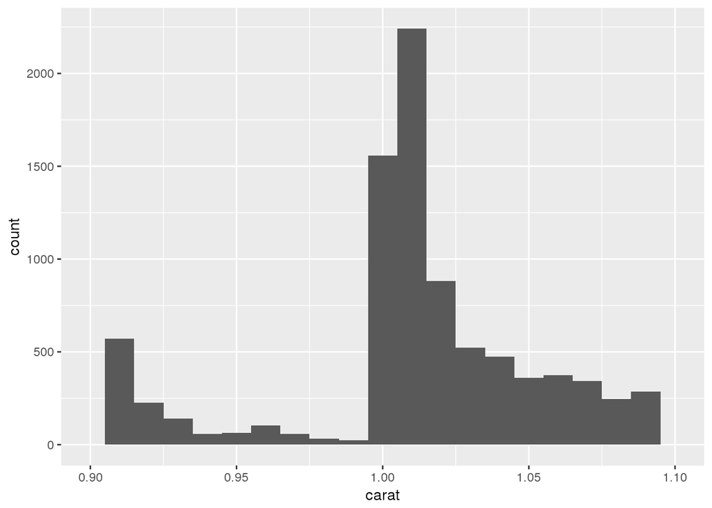

   ```r
   ggplot(diamonds, aes(x = carat)) +
     geom_histogram(binwidth = 0.01) +
     xlim(c(0.9, 1.1))
   ```

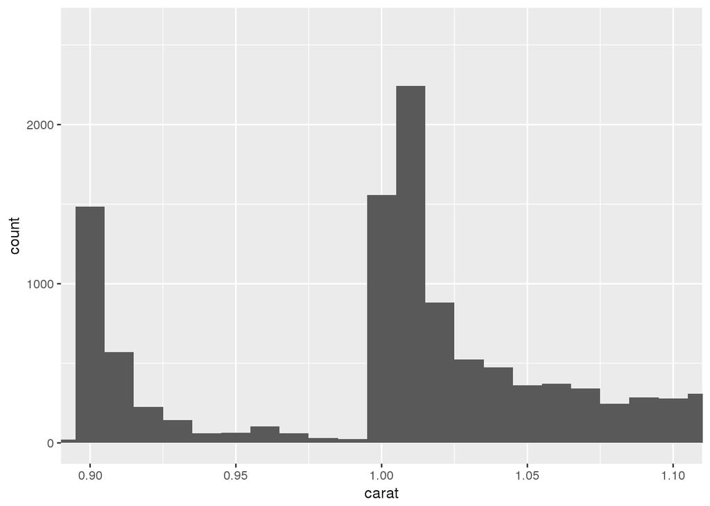

   ```r
   ggplot(diamonds, aes(x = carat)) +
     geom_histogram(binwidth = 0.01) +
     coord_cartesian(xlim = c(0.9, 1.1))
   ```

7.4.1

1. What happens to missing values in a histogram? What happens to missing values in a bar chart? Why is there a difference?

   In a histogram, the missing values are dropped. In a bar chart, missing values (NA) are considered another category since the geom_bar function is for discrete variables.

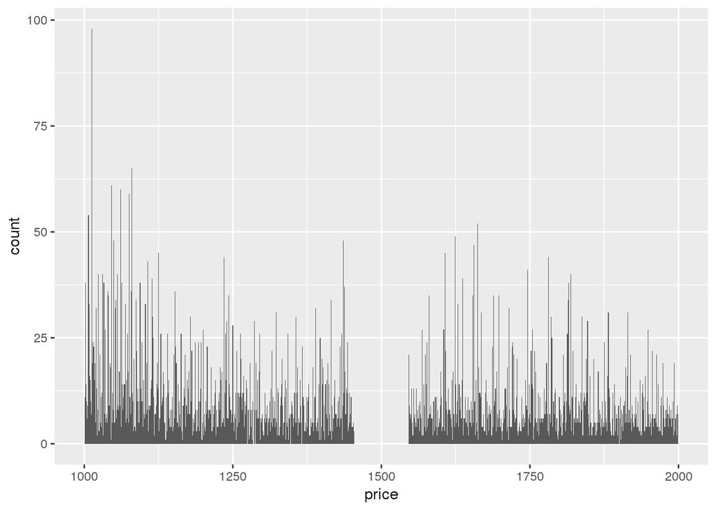

   ```r
   ggplot(data = diamonds) +
     geom_histogram(aes(x = price), binwidth = 1) +
     xlim(c(1000, 2000))
   ```

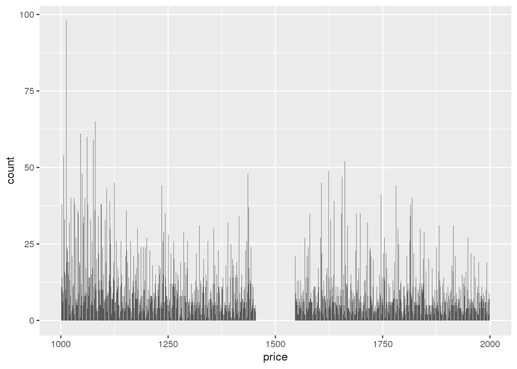

   ```r
   ggplot(data = diamonds) +
     geom_bar(aes(x = price)) +
     xlim(c(1000, 2000))
   ```

2. What does na.rm = TRUE do in mean() and sum()?

   In mean() and sum(), na.rm = TRUE is a logical value indicating that NA values should be stripped before the computation proceeds.

7.5.1.1

1. Use what you’ve learned to improve the visualisation of the departure times of cancelled vs. non-cancelled flights.

   I improved the visualisation.

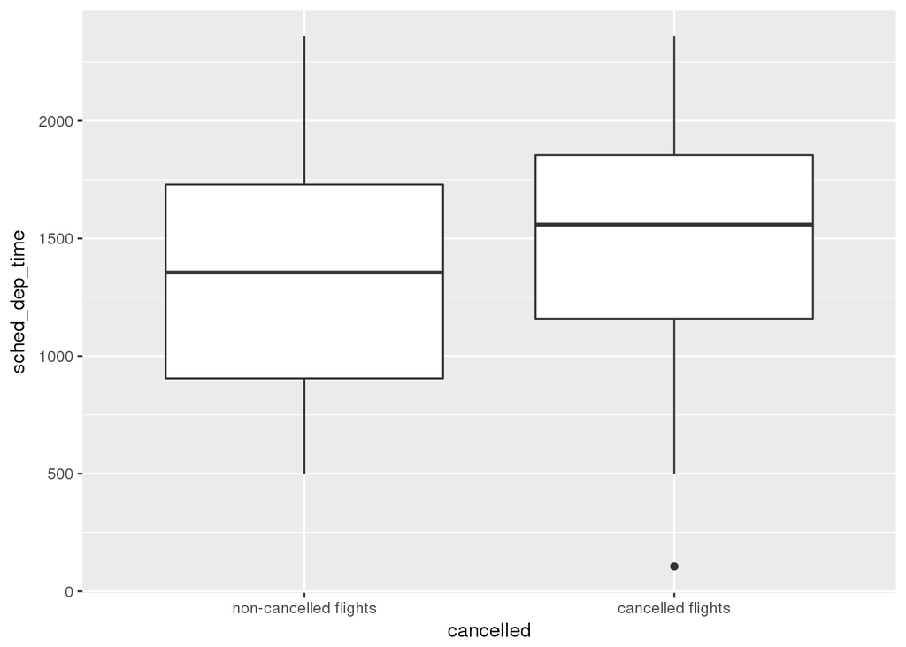

   ```r
   flights %>%
     mutate(cancelled = is.na(dep_time)) %>%
     ggplot() +
     geom_boxplot(aes(x = cancelled, y = sched_dep_time)) +
     scale_x_discrete(labels = c("non-cancelled flights", "cancelled flights"))
   ```

2. What variable in the diamonds dataset is most important for predicting the price of a diamond? How is that variable correlated with cut? Why does the combination of those two relationships lead to lower quality diamonds being more expensive?

   It seems that carat is the most important variable for predicting the price of a diamond.

   It looks like the better the cut is, the lower the carat is.

   It might be because the better cut makes the carat lower, resulting in a lower price.

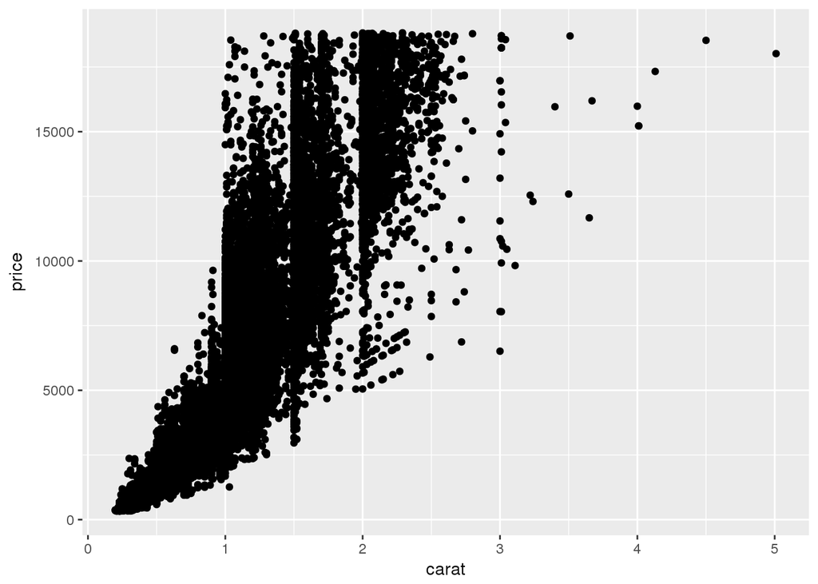

   ```r
   ggplot(diamonds, aes(x = carat, y = price)) +
     geom_point()
   ```

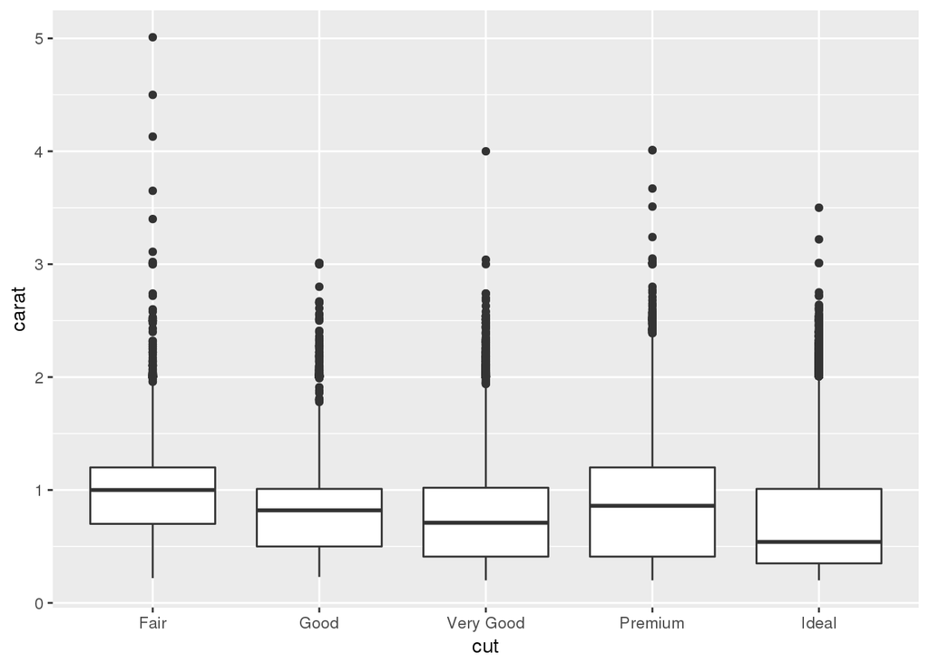

   ```r
   ggplot(diamonds, aes(x = cut, y = carat)) +
     geom_boxplot()
   ```

3. Install the ggstance package, and create a horizontal boxplot. How does this compare to using coord_flip()?